# Seminaroppgaver, STV4022, uke 1

Jørgen Bølstad

### Forberedelser

For å løse seminaroppgavene må du installere R, [RStudio](https://www.rstudio.com/products/rstudio/download/#download), og R-pakken rstanarm på maskinen din. Det kan også være nyttig å installere pakken `tidyverse`.

Last inn datasettet `earnings` fra kapittel 5 i Gelman et al. Dette kan enten lastes ned fra [nettsiden](https://avehtari.github.io/ROS-Examples/examples.html) til boken, eller ved å installere R-pakken rosdata (instruksjoner for å gjøre dette ligger også på [nettsiden](https://avehtari.github.io/ROS-Examples/examples.html)). Hvis du installerer R-pakken kan du laste inn datasettet ved å kjøre kommandoen `data(earnings)`.

```r
library(rosdata)
data("earnings")
```

Legg analysene og svarene dine inn i et .Rmd-dokument, slik at du kan levere inn en html-fil som både viser kodene dine, plottene dine, og svarene dine.

### Oppgave 1

Gjør deg kjent med datasettet.

- Hvilke variabler inneholder det?

```r
# Det er flere måte å utforske dataene på.
# Noen relevante kommandoer kan være str(), head(), tail() og summary().
head(earnings)
```

```
##   height weight male  earn earnk ethnicity education mother_education
## 1     74    210    1 50000    50     White        16               16
## 2     66    125    0 60000    60     White        16               16
## 3     64    126    0 30000    30     White        16               16
## 4     65    200    0 25000    25     White        17               17
## 5     63    110    0 50000    50     Other        16               16
## 6     68    165    0 62000    62     Black        18               18
##   father_education walk exercise smokenow tense angry age
## 1               16    3        3        2     0     0  45
## 2               16    6        5        1     0     0  58
## 3               16    8        1        2     1     1  29
## 4               NA    8        1        2     0     0  57
## 5               16    5        6        2     0     0  91
## 6               18    1        1        2     2     2  54
```

```r
str(earnings)
```

```
## 'data.frame':    1816 obs. of  15 variables:
##  $ height          : int  74 66 64 65 63 68 63 64 62 73 ...
##  $ weight          : int  210 125 126 200 110 165 190 125 200 230 ...
##  $ male            : int  1 0 0 0 0 0 0 0 0 1 ...
##  $ earn            : num  50000 60000 30000 25000 50000 62000 51000 9000 29000 32000 ...
##  $ earnk           : num  50 60 30 25 50 62 51 9 29 32 ...
##  $ ethnicity       : chr  "White" "White" "White" "White" ...
##  $ education       : int  16 16 16 17 16 18 17 15 12 17 ...
##  $ mother_education: int  16 16 16 17 16 18 17 15 12 17 ...
##  $ father_education: int  16 16 16 NA 16 18 17 15 12 17 ...
##  $ walk            : int  3 6 8 8 5 1 3 7 2 7 ...
##  $ exercise        : int  3 5 1 1 6 1 1 4 2 1 ...
##  $ smokenow        : int  2 1 2 2 2 2 2 1 2 1 ...
##  $ tense           : int  0 0 1 0 0 2 4 4 0 0 ...
##  $ angry           : int  0 0 1 0 0 2 4 4 0 0 ...
##  $ age             : int  45 58 29 57 91 54 39 26 49 46 ...
```

- Hvor mange observasjoner inneholder det?

```r
nrow(earnings)
```

```
## [1] 1816
```

### Oppgave 2

- Lag tetthetsplott (*density plot*) eller et histogram for inntektsvariabelen (`earn`). Bruk enten ggplot2 eller vanlig R-plotting.

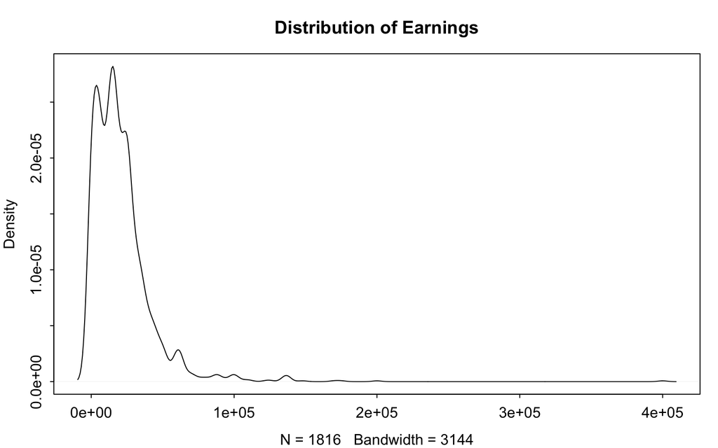

```r
# Tetthetsplot via vanlig R plotting:
par(mar=c(3,3,3,1),  mgp=c(2,.5,0), tck=-.01)
plot(density(earnings$earn), main = "Distribution of Earnings")
```

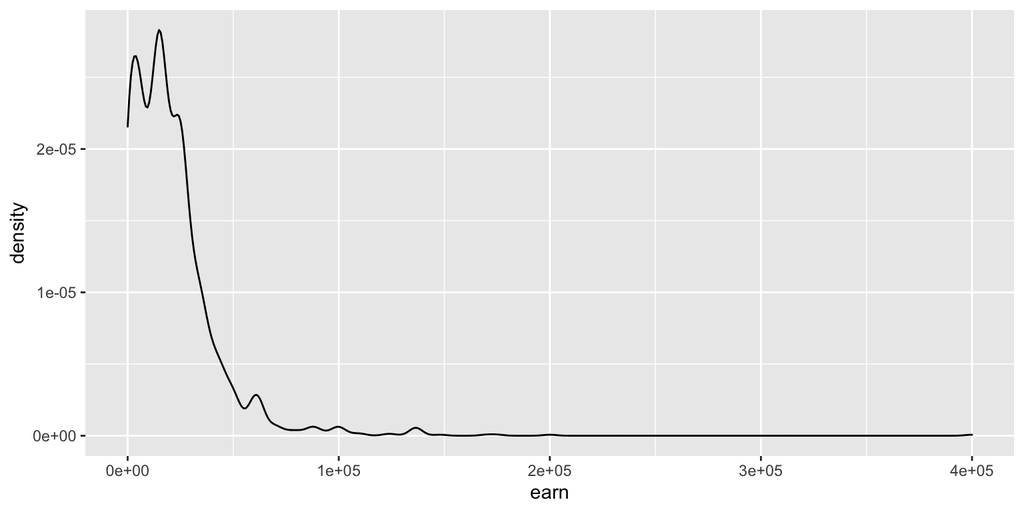

```r
# Tetthetsplot i ggplot:
library(ggplot2)
ggplot(earnings, aes(x = earn)) + geom_density(alpha=0.5)
```

- Vurdér om det kan være hensiktsmessig å transformere variabelen. Lag i så fall et nytt plott.

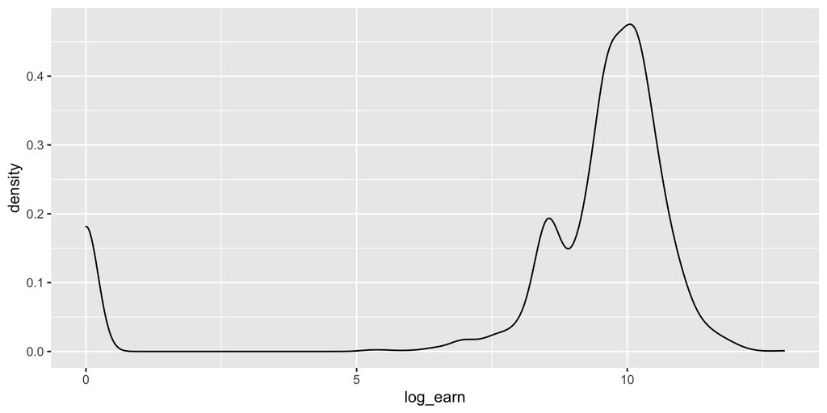

```r
# Det kan være hensiktsmessig å log-transformere fordi det er noen ekstremt høye verdier øverst på skalaen,
# mens de fleste observasjonene er samlet nederst. Vi log-transformerer derfor i resten av svarene.

# Det er imidlertid flere personer i dataene som har 0 i inntekt. Logaritmen av 0 er uendelig negativ.
# Dersom disse personene hadde hatt 1 dollar i inntekt, ville logaritmen av inntekten deres vært 0.
# For å unngå at de droppes fra plottene, kan det derfor kanskje forsvares å kode disse inntektene som 0.
# NB: Dette er ikke noen generelt gyldig tilnærming, og vil ikke nødvendigvis kunne forsvares i andre
# tilfeller -- særlig ikke hvis dataene inneholder verdier mellom 0 og 1 som har negative logaritmer.

earnings$log_earn <- log(earnings$earn) # Lag en logaritmisk versjon av variabelen
earnings$log_earn[!is.finite(earnings$log_earn)] <- 0 # Kod om uendelige verdier til 0
ggplot(earnings, aes(x = log_earn)) + geom_density(alpha = 0.5) # Lag et nytt plott
```

### Oppgave 3

- Kod om kjønnsvariabelen til en faktorvariabel.

```r
earnings$male <- factor(earnings$male, levels = c(0, 1), labels = c("Women", "Men"))
```

- Lag et nytt plott som skiller mellom menn og kvinner, slik at du får to fordelinger i ett plott.
- Legg til vertikale linjer som viser medianinntekten for hvert kjønn.
- Hva viser plottet?

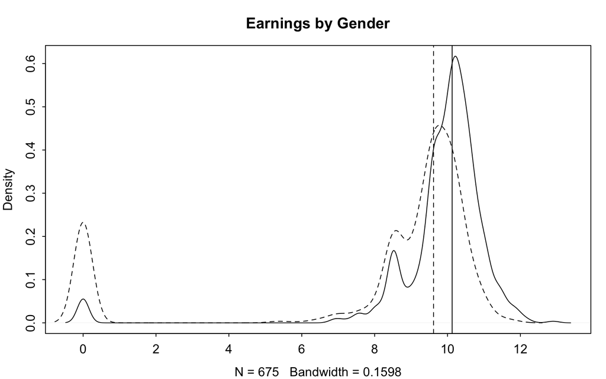

```r
# Tetthetsplott i vanlig R:
par(mar=c(3,3,3,1),  mgp=c(2,.5,0), tck=-.01)
plot(density(earnings$log_earn[earnings$male=="Men"]), main = "Earnings by Gender")
abline(v=median(earnings$log_earn[earnings$male=="Men"]), lty = 1)
lines(density(earnings$log_earn[earnings$male=="Women"]), lty = 2)
abline(v=median(earnings$log_earn[earnings$male=="Women"]), lty = 2)
```

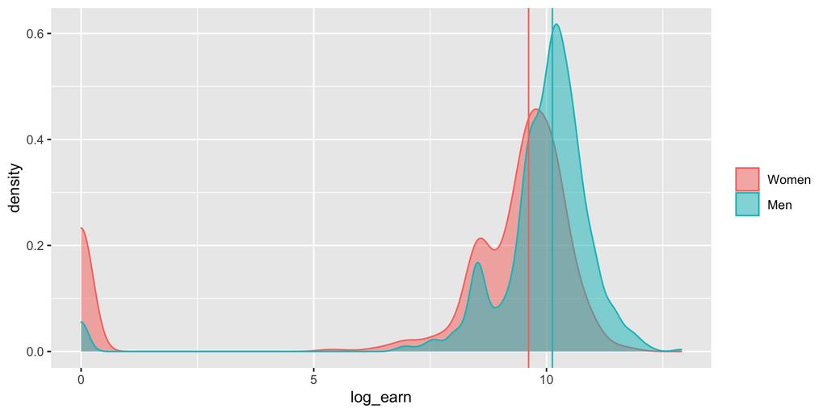

```r
# Tetthetsplott i ggplot:
ggplot(earnings, aes(x = log_earn, color = male, fill = male)) + geom_density(alpha=0.5) +
  geom_vline(xintercept = median(earnings$log_earn[earnings$male=="Men"]), color = "#00BFC4") +
  geom_vline(xintercept = median(earnings$log_earn[earnings$male=="Women"]), color = "#F8766D") +
  theme(legend.title = element_blank())
```

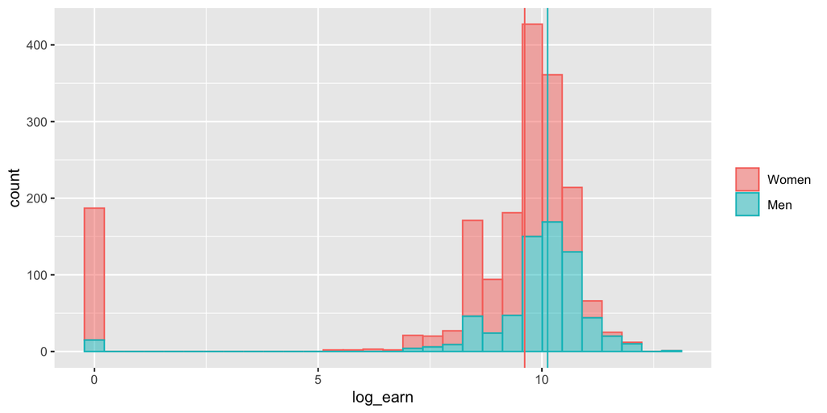

```r
# Histogram i ggplot:
# (Ulempen med histogram i dette tilfellet er at det er en overvekt av kvinner i datasettet,
# slik at frekvensene deres blir høyere og ikke direkte sammenlignbare med mennenes.)
ggplot(earnings, aes(x = log_earn, color = male, fill = male)) + geom_histogram(alpha=0.5) +
  geom_vline(xintercept = median(earnings$log_earn[earnings$male=="Men"]), color = "#00BFC4") +
  geom_vline(xintercept = median(earnings$log_earn[earnings$male=="Women"]), color = "#F8766D") +
  theme(legend.title = element_blank())
```

### Ekstraoppgaver for de med liten kjennskap til R

Jobb med [arbeidsboken](https://avehtari.github.io/ROS-Examples/examples.html). Hvis du er ferdig med den, gå til oppgavene under.

### Ekstraoppgaver for de med mer kjennskap til R

- Velg deg et tema du er interessert i, og finn et relevant datasett på nettet. Se for eksempel hos [nsd](https://www.nsd.no) eller [gesis](https://www.gesis.org/en/services/finding-and-accessing-data).
- Last inn datasettet i R og gjør deg kjent med det. (Datasett kan komme i mange ulike formater som vil kreve ulike innlastingsfunksjoner i R. Søk på nettet eller spør seminarleder om du er usikker på hvordan ditt format bør lastes inn. Hvis du står fast på dette punktet, og ikke kommer i mål før seminaret er over, trenger du ikke fullføre denne oppgaven.)
- Identifisér noen variabler du synes er interessante.
  - Sjekk hvordan disse variablene er kodet. Kod dem om dersom det er nødvendig.
  - Lag grafiske fremstillinger av fordelinger for enkeltvariabler eller sammenhenger mellom utvalgte variabler.
  - Gjør plottene så gode og presentable som du klarer.
  - Hva viser plottene dine?